# Chapter5

Justin Box

12/2/2018

```r
library(dplyr)
library(tidyr)
library(ggplot2)
library(corrplot)
library(GGally)
library(FactoMineR)
options(scipen=999)
```

# IODS Week 5

## Description of the Data

“HDI.Rank” = Country rank in Human Development Index “Country”  
“HDI” = Human Development Index  
“L.Exp.Birth” = Life expectancy at birth  
“Exp.Yr.Ed” = Expected years of schooling  
“Mean.Yr.Ed” = Mean years of schooling  
“GNIperCap” = Gross national income (GNI) per capita  
“GNIperCap-HDI.Rank” = Gross national income (GNI) per capita - Human Development Index “GII.Rank”= Country rank in Gender Inequality Index “GII” = Gender Inequality Index  
“Mat.Mort.Rat” = Maternal mortality ratio  
“Ad.Birth.Rate” = Adolescent birth rate  
“%Rep.in.Par” = Percetange of female representatives in parliament  
“Pop.w.2nd.Ed.F” = Population of women with at least some secondary education “Pop.w.2nd.Ed.M” = Population of men with at least some secondary education “Lab.Part.Rate.F” = Population of women participating in labor “Lab.Part.Rate.M” = Population of men participating in labor “Edu2.FM” = The ratio of Female / Male populations with secondary education (edu2F / edu2M) “Labo.FM” = The ratio of Female / Male participation in labour force (work2F / work2M)

More information about the dataset can be found [here](http://hdr.undp.org/en/content/human-development-index-hdi) and [here](http://hdr.undp.org/sites/default/files/hdr2015_technical_notes.pdf).

```r
url = "http://s3.amazonaws.com/assets.datacamp.com/production/course_2218/datasets/human2.txt"
human <- read.table(url, sep=",", header=TRUE)
```

## Visualization

In this graph, blue circles indicate positive correlations and red indicate negative. Size and intensity of the circle reflect the strength of the correlation.

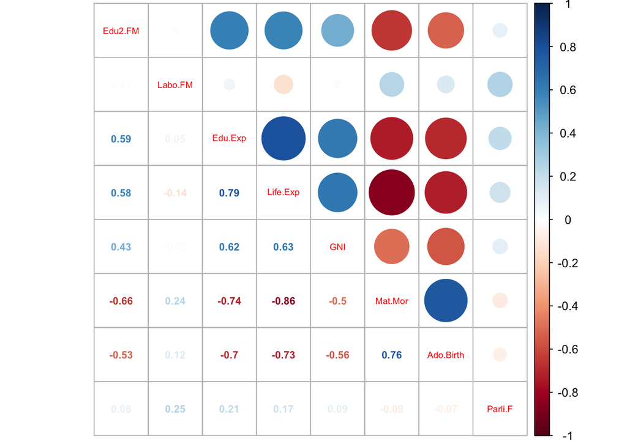

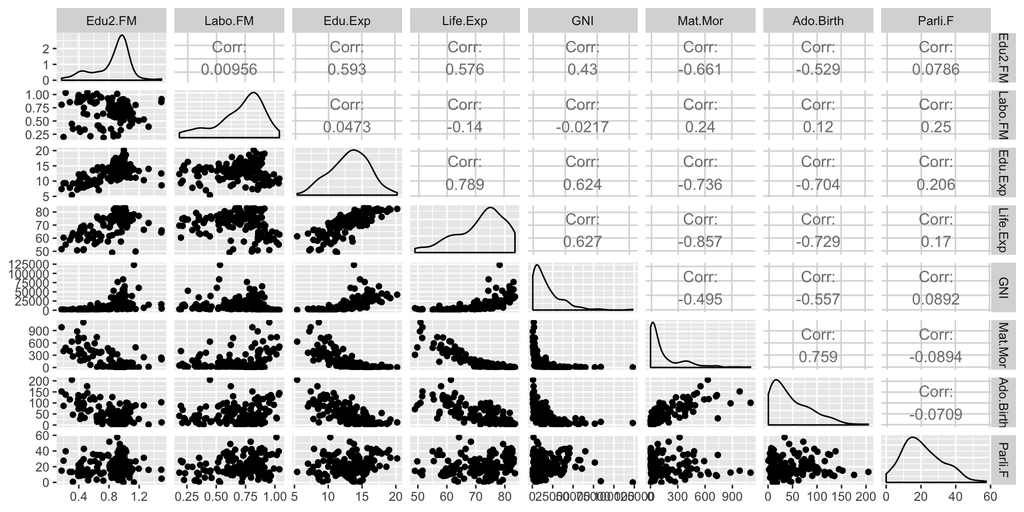

```r
# calculate the correlation matrix and round it
cor_matrix<-cor(human) %>% round(digits = 2)
# visualize the correlation matrix
corrplot.mixed(cor_matrix, number.cex = .7, tl.pos = "d", tl.cex = 0.6)
```

From this graph, we can see that there is a strong correlation between education Edu.Exp and life expectancy Life.Exp, GNI, maternal mortality Mat.Mor and adolescent birth rate Ado.Birth. Life expectancy Life.Exp is naturally linked to Mat.Mor and Ado.Birth (negative).

## Principal Component Analysis

A principal component analysis (PCA) is first performed on the non-standardized data. The following biplot shows the observations by the first two principal components (PC1, PC2). The arrow and its length represent the correlation between the feature and the corresponding principal component.

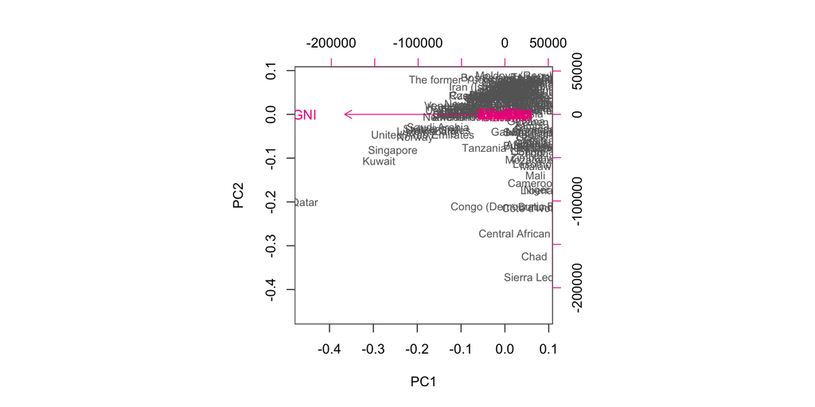

GNI appears to be the only varaible correlated to PC1. However, this is due to its large range compared to others within the dataset. This affects the interpretation of the plot and which variables hare actually having an effect.

The dataset is then re-standardized and PCA done again. Here is the summary of the new normalized dataset:

```
##     Edu2.FM           Labo.FM           Edu.Exp           Life.Exp
##  Min.   :-2.8189   Min.   :-2.6247   Min.   :-2.7378   Min.   :-2.7188
##  1st Qu.:-0.5233   1st Qu.:-0.5484   1st Qu.:-0.6782   1st Qu.:-0.6425
##  Median : 0.3503   Median : 0.2316   Median : 0.1140   Median : 0.3056
##  Mean   : 0.0000   Mean   : 0.0000   Mean   : 0.0000   Mean   : 0.0000
##  3rd Qu.: 0.5958   3rd Qu.: 0.7350   3rd Qu.: 0.7126   3rd Qu.: 0.6717
##  Max.   : 2.6646   Max.   : 1.6632   Max.   : 2.4730   Max.   : 1.4218
##       GNI             Mat.Mor          Ado.Birth          Parli.F
##  Min.   :-0.9193   Min.   :-0.6992   Min.   :-1.1325   Min.   :-1.8203
##  1st Qu.:-0.7243   1st Qu.:-0.6496   1st Qu.:-0.8394   1st Qu.:-0.7409
##  Median :-0.3013   Median :-0.4726   Median :-0.3298   Median :-0.1403
##  Mean   : 0.0000   Mean   : 0.0000   Mean   : 0.0000   Mean   : 0.0000
##  3rd Qu.: 0.3712   3rd Qu.: 0.1932   3rd Qu.: 0.6030   3rd Qu.: 0.6127
##  Max.   : 5.6890   Max.   : 4.4899   Max.   : 3.8344   Max.   : 3.1850
```

The biplot is drawn again but this time using the scaled dataset.

Education **Edu.Exp**, **Edu2.FM** is negatively correlated to adolescent birth **Ado.Birth**, while life expectancy **Life.Exp** is negatively correlated to maternal mortality **Mat.Mor**. Gross national income **GNI** directly goes together with education and life expectancy, while against mortality and teenage birth, as expected. Female anticipation in parliment **Parli.F** can be somewhat related to ratio of female and male in the workforce **Labo.FM**.

[figure not shown]

### Interpretation

Because **Parli.F** and **Labo.FM** align with **PC2**, and **Edu.Exp**, **Edu2.FM**, **Life.Exp**,**GNI**, **Mat.Mor** and **Ado.Birth** align with **PC1**, it can be inferred that the principal components have their implicit meanings.

For **PC1**, it’s understandable to see education, income and life expectancy being related as they complement each other in real life. Poor education could lead to lack of opportunity and/or upward social mobility and therefore high adolescent birth rate, and subsequently maternal mortality. This mortality also directly affects life expectancy.

This principal component **PC1** therefore reflects **Health and knowledge** and its effects.

For **PC2**, it’s more about **Gender empowerment**. It could be inferred that as females become more prominent in the workforce, they end up being more politically active, which is a common finding in countries where gender equality is well documented.

## Tea Dataset

The **tea** dataset from **FactoMineR** library contains a very comprehensive research on how tea is consumed, including where, how, in which environment, etc. **age** is the only variable with integer values, while the rest contain categorical values, which are self-explanatory.

### Loading the Data

```
## 'data.frame':    300 obs. of  36 variables:
##  $ breakfast       : Factor w/ 2 levels "breakfast","Not.breakfast": 1 1 2 2 1 2 1 2 1 1 ...
##  $ tea.time        : Factor w/ 2 levels "Not.tea time",..: 1 1 2 1 1 1 2 2 2 1 ...
##  $ evening         : Factor w/ 2 levels "evening","Not.evening": 2 2 1 2 1 2 2 1 2 1 ...
##  $ lunch           : Factor w/ 2 levels "lunch","Not.lunch": 2 2 2 2 2 2 2 2 2 2 ...
##  $ dinner          : Factor w/ 2 levels "dinner","Not.dinner": 2 2 1 1 2 1 2 2 2 2 ...
##  $ always          : Factor w/ 2 levels "always","Not.always": 2 2 2 2 1 2 2 2 2 2 ...
##  $ home            : Factor w/ 2 levels "home","Not.home": 1 1 1 1 1 1 1 1 1 1 ...
##  $ work            : Factor w/ 2 levels "Not.work","work": 1 1 2 1 1 1 1 1 1 1 ...
##  $ tearoom         : Factor w/ 2 levels "Not.tearoom",..: 1 1 1 1 1 1 1 1 1 2 ...
##  $ friends         : Factor w/ 2 levels "friends","Not.friends": 2 2 1 2 2 2 1 2 2 2 ...
##  $ resto           : Factor w/ 2 levels "Not.resto","resto": 1 1 2 1 1 1 1 1 1 1 ...
##  $ pub             : Factor w/ 2 levels "Not.pub","pub": 1 1 1 1 1 1 1 1 1 1 ...
##  $ Tea             : Factor w/ 3 levels "black","Earl Grey",..: 1 1 2 2 2 2 2 1 2 1 ...
##  $ How             : Factor w/ 4 levels "alone","lemon",..: 1 3 1 1 1 1 1 3 3 1 ...
```

[output cut: 22 more lines]

```
## [1] 300  36
```

### Variable Selection

Next, 6 variables were selected: “Tea”, “How”, “how”, “sugar”, “where”, “lunch”. These will be the focus of my analysis.

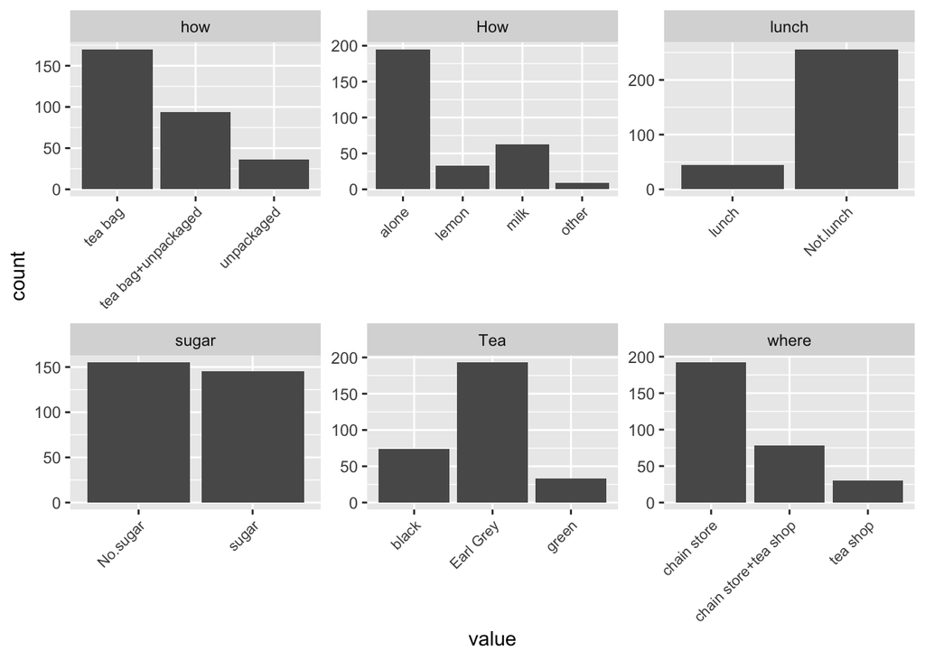

## Multiple Correspondence Analysis

The table below is a summary of the MCA model performed on the tea dataset. As can be seen from the categorical variables, the way tea is packaged **how** and **where** it is used are closely related to **Dim.1**, as well as **Dim.2**. Meanwhile, the kind of **Tea** and **How** they are drank are related to **Dim.3**.

```
##
## Call:
## MCA(X = tea_time, graph = FALSE)
##
##
## Eigenvalues
##                        Dim.1   Dim.2   Dim.3   Dim.4   Dim.5   Dim.6
## Variance               0.279   0.261   0.219   0.189   0.177   0.156
## % of var.             15.238  14.232  11.964  10.333   9.667   8.519
## Cumulative % of var.  15.238  29.471  41.435  51.768  61.434  69.953
##                        Dim.7   Dim.8   Dim.9  Dim.10  Dim.11
## Variance               0.144   0.141   0.117   0.087   0.062
## % of var.              7.841   7.705   6.392   4.724   3.385
## Cumulative % of var.  77.794  85.500  91.891  96.615 100.000
##
## Individuals (the 10 first)
##                       Dim.1    ctr   cos2    Dim.2    ctr   cos2    Dim.3
## 1                  | -0.298  0.106  0.086 | -0.328  0.137  0.105 | -0.327
## 2                  | -0.237  0.067  0.036 | -0.136  0.024  0.012 | -0.695
## 3                  | -0.369  0.162  0.231 | -0.300  0.115  0.153 | -0.202
## 4                  | -0.530  0.335  0.460 | -0.318  0.129  0.166 |  0.211
## 5                  | -0.369  0.162  0.231 | -0.300  0.115  0.153 | -0.202
## 6                  | -0.369  0.162  0.231 | -0.300  0.115  0.153 | -0.202
## 7                  | -0.369  0.162  0.231 | -0.300  0.115  0.153 | -0.202
## 8                  | -0.237  0.067  0.036 | -0.136  0.024  0.012 | -0.695
## 9                  |  0.143  0.024  0.012 |  0.871  0.969  0.435 | -0.067
## 10                 |  0.476  0.271  0.140 |  0.687  0.604  0.291 | -0.650
##                       ctr   cos2
## 1                   0.163  0.104 |
## 2                   0.735  0.314 |
## 3                   0.062  0.069 |
## 4                   0.068  0.073 |
## 5                   0.062  0.069 |
## 6                   0.062  0.069 |
## 7                   0.062  0.069 |
## 8                   0.735  0.314 |
## 9                   0.007  0.003 |
## 10                  0.643  0.261 |
##
## Categories (the 10 first)
```

[output cut: 16 more lines]

```
## lemon                0.035   3.226 |   1.329  14.771   0.218   8.081 |
## milk                 0.020   2.422 |   0.013   0.003   0.000   0.116 |
## other                0.102   5.534 |  -2.524  14.526   0.197  -7.676 |
## tea bag              0.161  -6.941 |  -0.065   0.183   0.006  -1.287 |
## tea bag+unpackaged   0.478  11.956 |   0.019   0.009   0.000   0.226 |
## unpackaged           0.141  -6.482 |   0.257   0.602   0.009   1.640 |
##
## Categorical variables (eta2)
##                      Dim.1 Dim.2 Dim.3
## Tea                | 0.126 0.108 0.410 |
## How                | 0.076 0.190 0.394 |
## how                | 0.708 0.522 0.010 |
## sugar              | 0.065 0.001 0.336 |
## where              | 0.702 0.681 0.055 |
## lunch              | 0.000 0.064 0.111 |
```

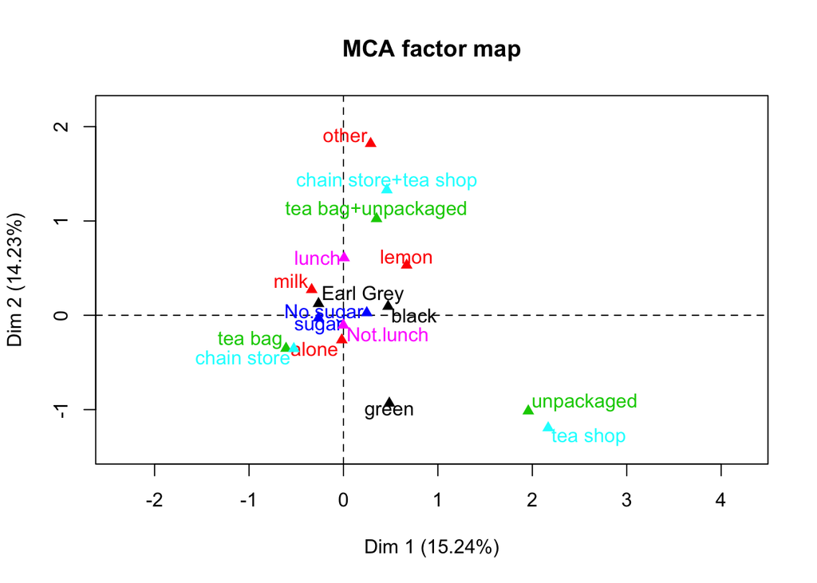